# Crime trends in London and other global cities

## Personal robbery: global cities

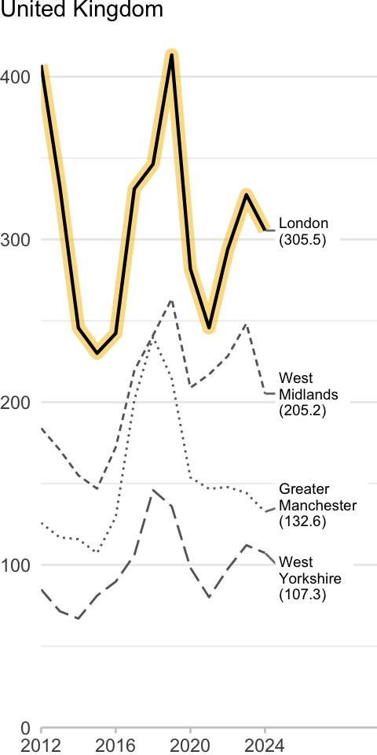

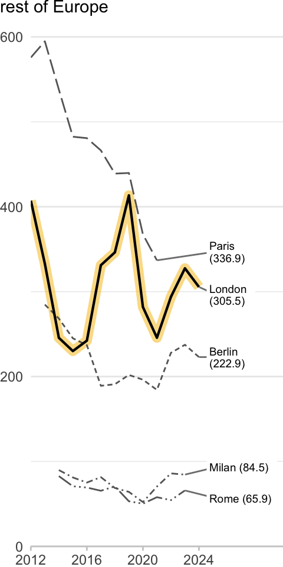

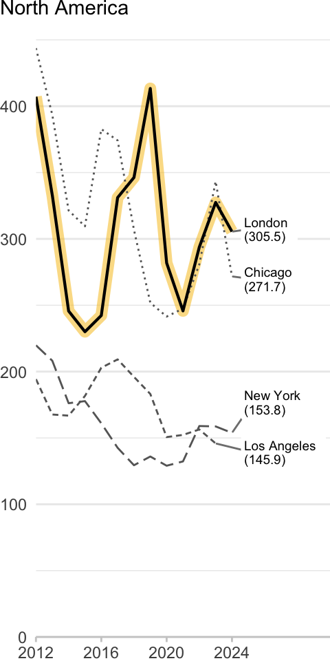

All rates are per 100,000 residents

## Business robbery: long-term trend in London

[figure not shown]

## Business robbery: global trends

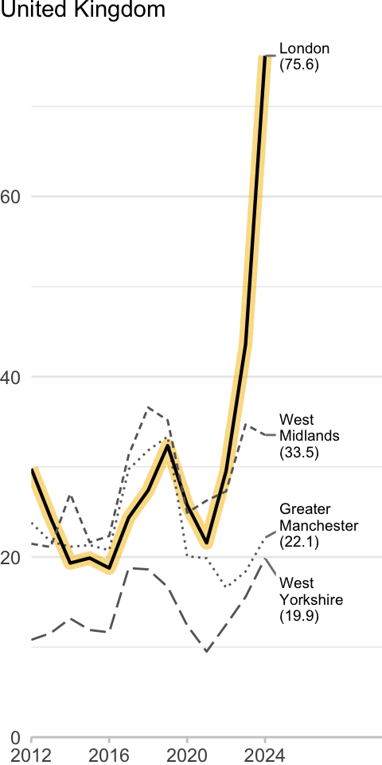

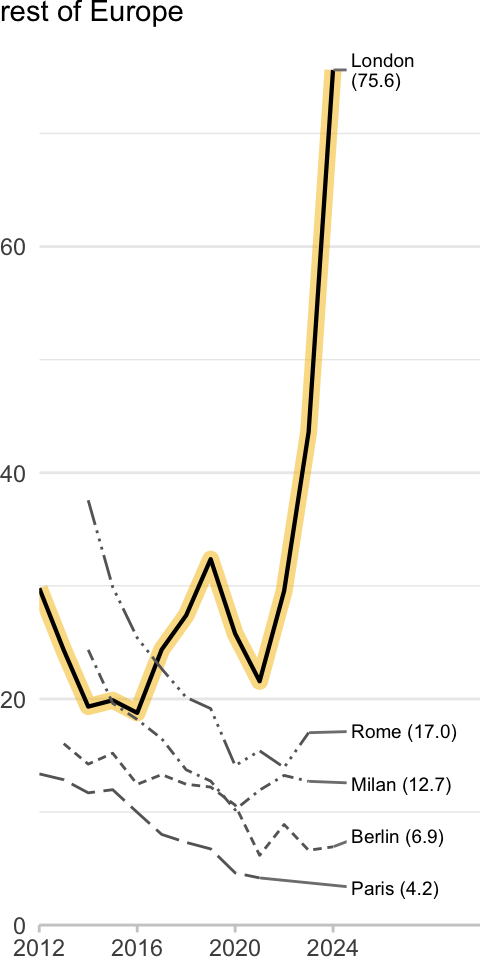

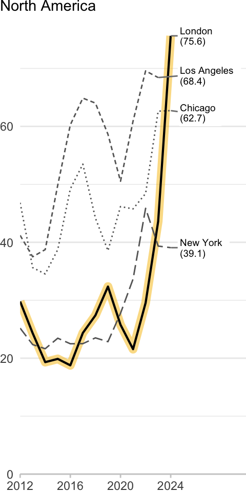

All rates are per 100,000 residents

## Residential burglary: long-term trend in London

[figure not shown]

## Residential burglary: global trends

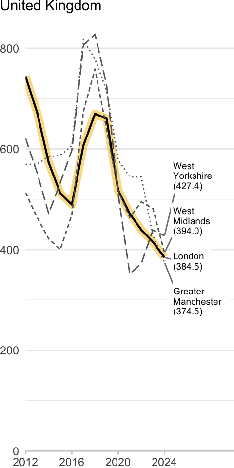

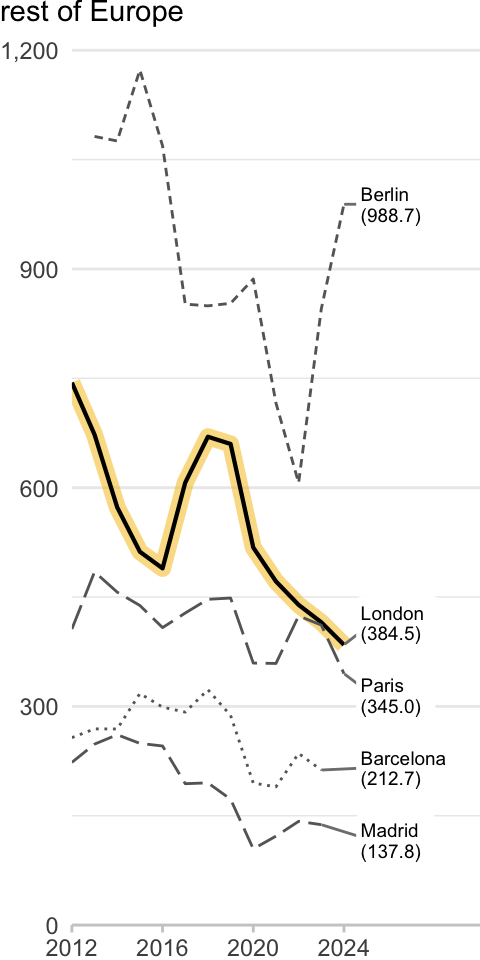

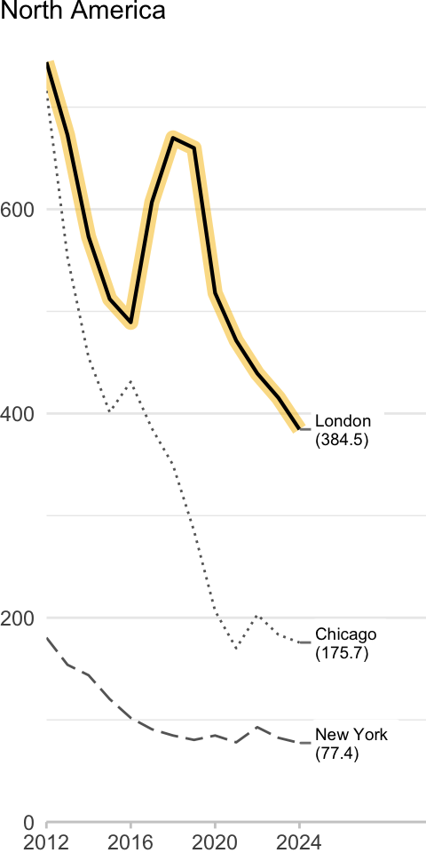

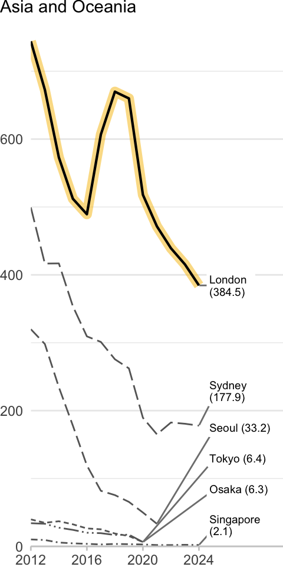

All rates are per 100,000 residents

## Theft of motor vehicle: long-term trend in London

[figure not shown]

## Theft of motor vehicle: global trends

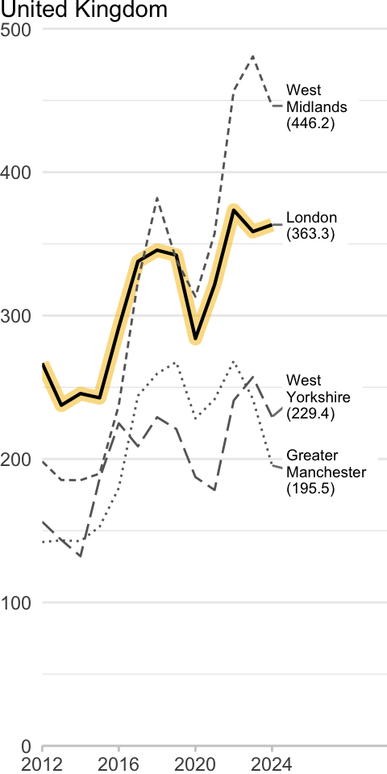

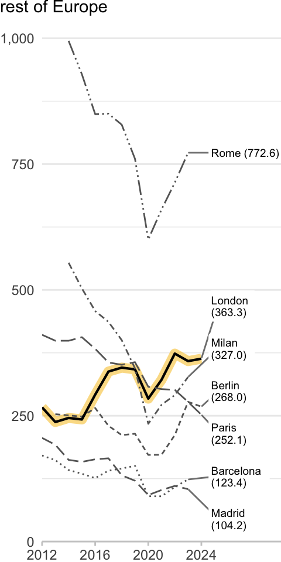

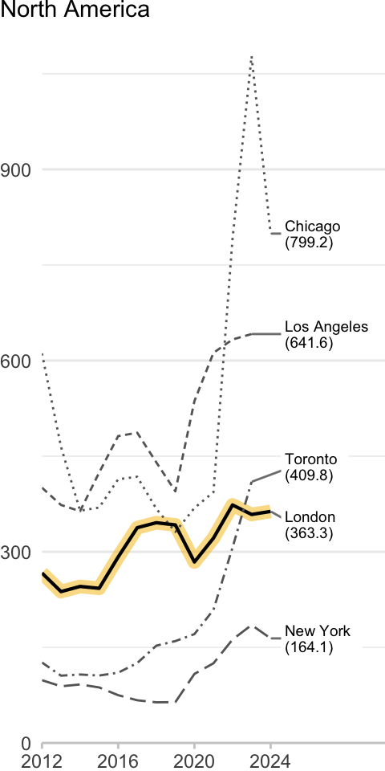

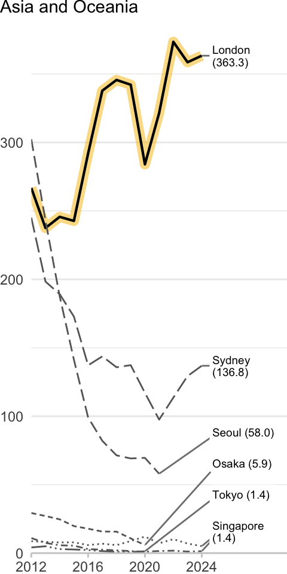

All rates are per 100,000 residents

## In summary

Comparing crime data across cities is hard

London has broadly similar crime rates to other large UK cities

London rates of most crimes are similar to other large European cities

London has much lower violence, and similar rates of property crime, to North American cities

Crime rates in London are typically higher than in Asian cities

# Questions?

matthew.ashby@ucl.ac.uk

These slides: **lesscrime.info/slides/gcb-siu-2025**